# Loratadine Project

Gabriel Philbin

2025-03-16

This project is an analysis of weekly Google searches for Loratadine, a medical drug used to relieve symptoms of hay fever. The data was taken from Google Trends. The analysis will look at how to best measure the trend of the Time Series, displays of seasonality and using the prophet function to forecast how Loratadine will trend throughout 2025.

This project included the installation of the prophet and readxl packages.

Import Data from Excel and make a data frame.

```r
loratadineDf <- (read_excel("C:/Users/gabri/Coursework 1/Coursework1Template/data/loratadine20-25.xlsx"))
loratadineDf <- data.frame(loratadineDf)
```

Rename Columns

```r
colnames(loratadineDf) <- c("ds" , "y")
head(loratadineDf)
```

```
##           ds  y
## 1 2020-01-05 10
## 2 2020-01-12 11
## 3 2020-01-19  9
## 4 2020-01-26 11
## 5 2020-02-02 10
## 6 2020-02-09 10
```

Creating Numeric Data Frame. Makes it easier for future calculations.

```r
loratadineDfn <- data.frame(lapply(loratadineDf, as.numeric))
head(loratadineDfn)
```

```
##           ds  y
## 1 1578182400 10
## 2 1578787200 11
## 3 1579392000  9
## 4 1579996800 11
## 5 1580601600 10
## 6 1581206400 10
```

Plot Data 2020 to 2025

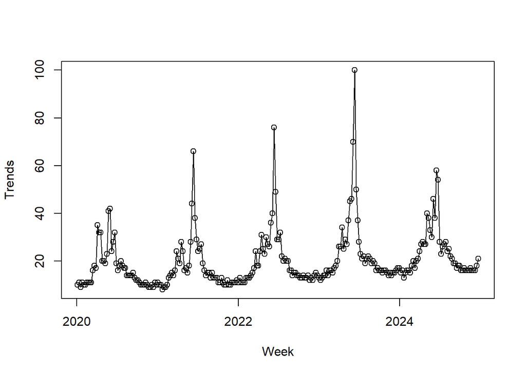

```r
plot(loratadineDf$ds, loratadineDf$y, type ="o", xlab="Week", ylab="Trends")
```

Looking at the plot of data, searches for Loratadine have very clear seasonal trends with searches peaking in the summer months consistently each year. As Loratadine is medication for hay fever, this is expected. The graph also shows a variation in the peak number of searches from year to year.

Fitting parametric models, linear, quadratic and cubic.

```r
ModelLi <- lm(y ~ ds, data=loratadineDfn)
summary(ModelLi)
```

```
##
## Call:
## lm(formula = y ~ ds, data = loratadineDfn)
##
## Residuals:
##    Min     1Q Median     3Q    Max
## -9.720 -6.932 -4.282  3.288 78.323
##
## Coefficients:
##               Estimate Std. Error t value Pr(>|t|)
## (Intercept) -6.913e+01  2.573e+01  -2.687 0.007683 **
## ds           5.385e-08  1.553e-08   3.468 0.000614 ***
## ---
## Signif. codes:  0 '***' 0.001 '**' 0.01 '*' 0.05 '.' 0.1 ' ' 1
##
## Residual standard error: 11.36 on 258 degrees of freedom
## Multiple R-squared:  0.04454,    Adjusted R-squared:  0.04083
## F-statistic: 12.03 on 1 and 258 DF,  p-value: 0.0006144
```

```r
ModelQu <- lm(y ~ ds + I(ds^2), data=loratadineDfn)
summary(ModelQu)
```

```
##
## Call:
## lm(formula = y ~ ds + I(ds^2), data = loratadineDfn)
##
## Residuals:
##    Min     1Q Median     3Q    Max
## -9.660 -7.022 -4.285  3.372 78.134
##
## Coefficients:
##               Estimate Std. Error t value Pr(>|t|)
## (Intercept) -5.122e+02  1.051e+03  -0.488    0.626
## ds           5.892e-07  1.269e-06   0.464    0.643
## I(ds^2)     -1.616e-16  3.830e-16  -0.422    0.673
##
## Residual standard error: 11.38 on 257 degrees of freedom
## Multiple R-squared:  0.0452, Adjusted R-squared:  0.03777
## F-statistic: 6.083 on 2 and 257 DF,  p-value: 0.002623
```

```r
ModelCu <- lm(y~ds+I(ds^2)+I(ds^3), data=loratadineDfn)
summary(ModelCu)
```

```
##
## Call:
## lm(formula = y ~ ds + I(ds^2) + I(ds^3), data = loratadineDfn)
##
## Residuals:
##     Min      1Q  Median      3Q     Max
## -10.762  -6.978  -3.716   3.061  76.663
##
## Coefficients:
##               Estimate Std. Error t value Pr(>|t|)
## (Intercept)  7.883e+04  4.343e+04   1.815   0.0707 .
## ds          -1.432e-04  7.871e-05  -1.820   0.0700 .
## I(ds^2)      8.670e-14  4.753e-14   1.824   0.0693 .
## I(ds^3)     -1.748e-23  9.565e-24  -1.827   0.0688 .
## ---
## Signif. codes:  0 '***' 0.001 '**' 0.01 '*' 0.05 '.' 0.1 ' ' 1
##
## Residual standard error: 11.33 on 256 degrees of freedom
## Multiple R-squared:  0.0575, Adjusted R-squared:  0.04645
## F-statistic: 5.206 on 3 and 256 DF,  p-value: 0.001663
```

Plot Linear Models against data.

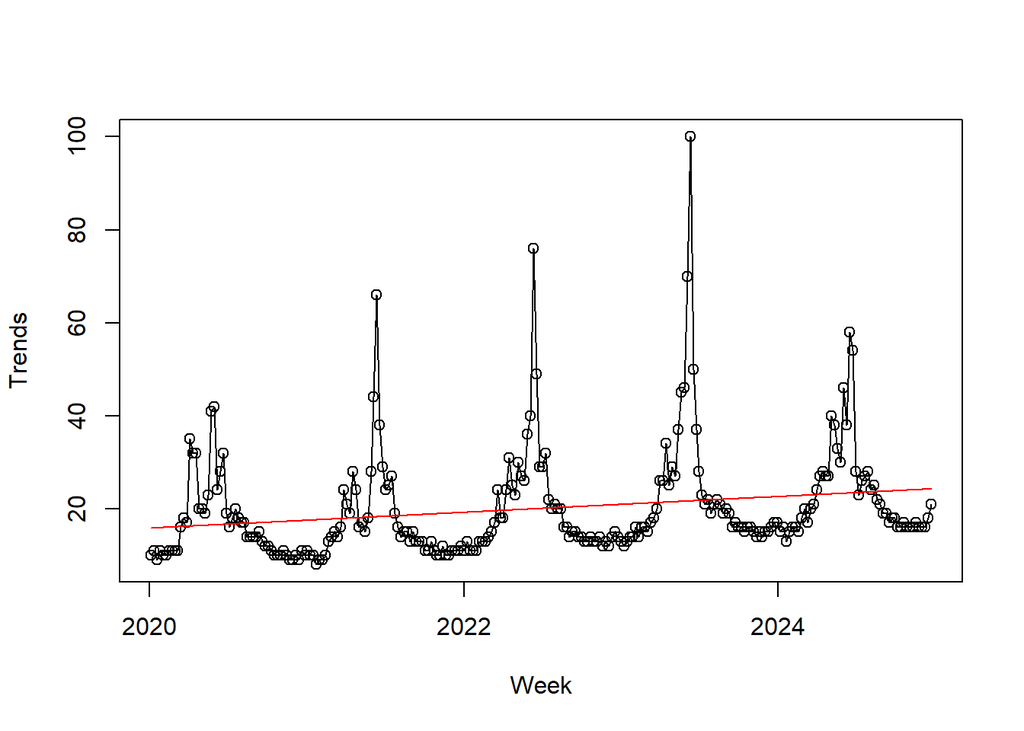

```r
plot(loratadineDf$ds, loratadineDf$y, type ="o", xlab="Week", ylab="Trends")
lines(loratadineDf$ds, fitted(ModelLi), col="red")
```

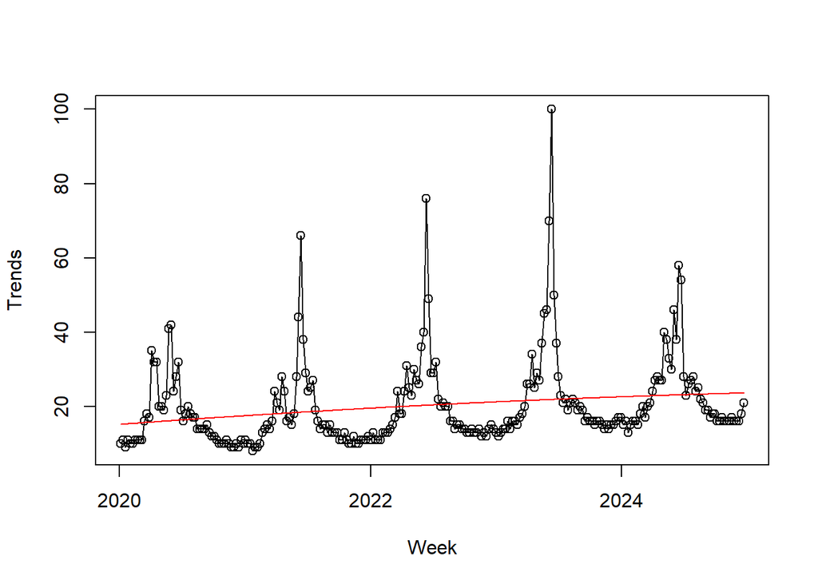

```r
plot(loratadineDf$ds, loratadineDf$y, type ="o", xlab="Week", ylab="Trends")
lines(loratadineDf$ds, fitted(ModelQu), col="red")
```

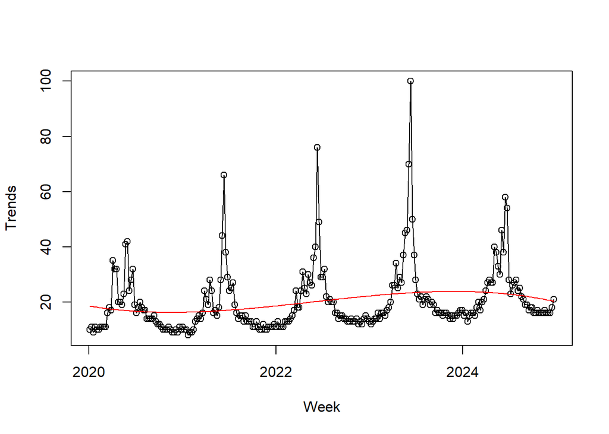

```r
plot(loratadineDf$ds, loratadineDf$y, type ="o", xlab="Week", ylab="Trends")
lines(loratadineDf$ds, fitted(ModelCu), col="red")
```

Here, linear, quadratic and cubic models have been fitted to the data using the lm function. Looking at their respective summaries, the cubic fit has the largest R-squared, 0.0575. This is very low indicating that none of these models are suitable fits for the data. Looking at their respective plots further supports this. This suggests that using parametric methods to estimate the trend is not a good idea.

Calculate 4 point moving average.

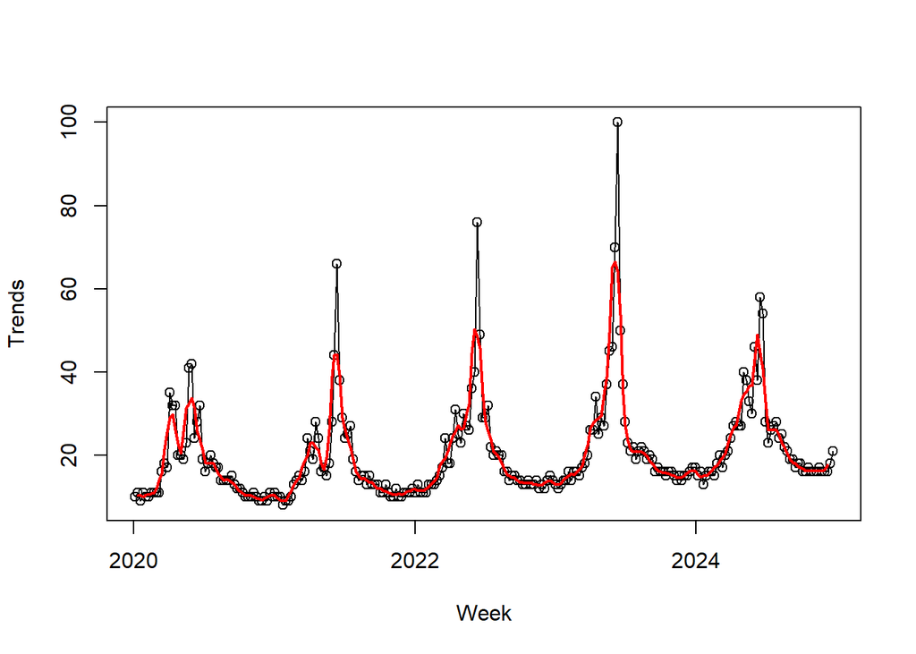

```r
loratadineAv4 <- stats::filter(loratadineDf$y, c(1/4, 1/4, 1/4, 1/4))
plot(loratadineDf$ds, loratadineDf$y, type ="o", xlab="Week", ylab="Trends")
lines(loratadineDf$ds, loratadineAv4, type="l", col="red", lwd=2)
```

A four point moving average of the data has been assigned to loratadineAv4. Plotting as a line against the original data shows that this is a much better representation of the trend than the regression models.

Spencer’s 15-point moving average

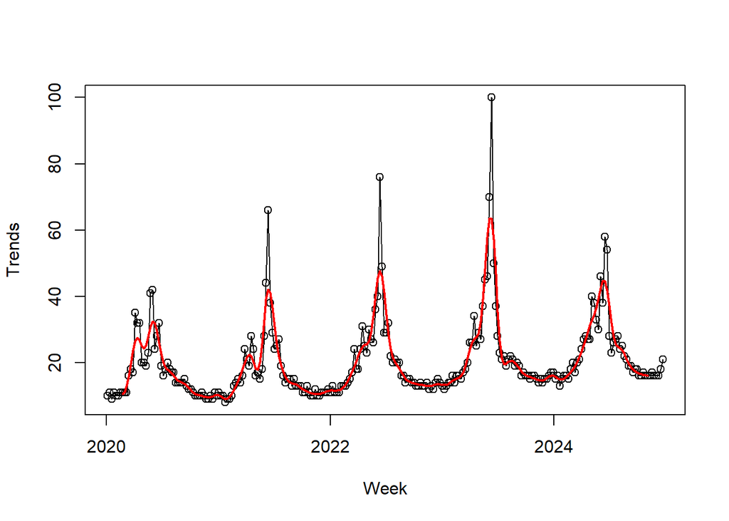

```r
Sp = signal::spencerFilter()
loratadineSp <- stats::filter(loratadineDf$y, Sp)
plot(loratadineDf$ds, loratadineDf$y, type ="o", xlab="Week", ylab="Trends")
lines(loratadineDf$ds, loratadineSp, type="l", col="red", lwd=2)
```

In this part, Spencer’s 15-point moving average has been applied to the data. With this filter, the seasonal peaks have been reduced in comparison to the 4-point moving average.

Holt Method

```r
loratadineHolt <- HoltWinters(loratadineDf$y, gamma = FALSE)
```

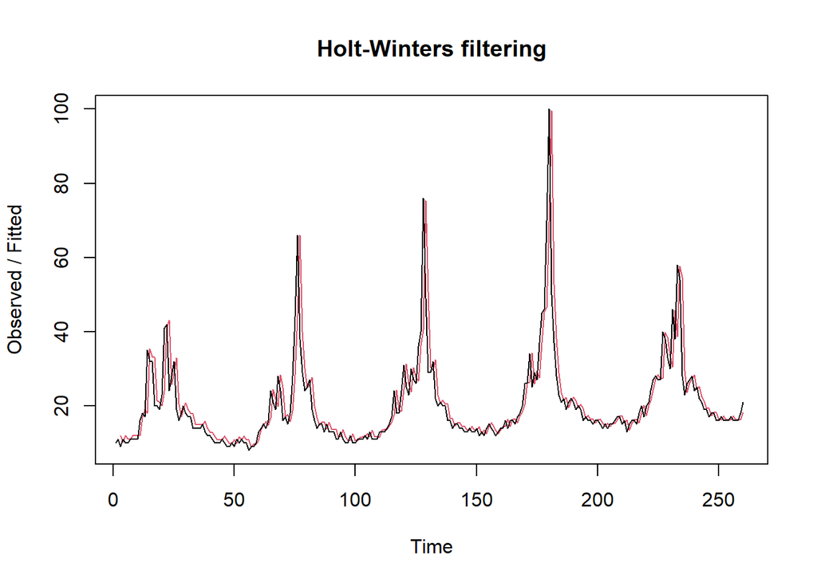

```r
plot(loratadineHolt)
```

Here, the Holt method has been applied to the data. Looking at the graph, the trend follows the data much more accurately than any of the previous methods. Therefore, this would be well suited to forecasting future trends in the interest of Loratadine.

Identifying seasonal component Creating Time Series of Data.

```r
loratadineTs <- ts(loratadineDf$y, start=c(2020,1), frequency=52)
loratadineDecomp =  stats::decompose(loratadineTs)
loratadineDecomp$seasonal
```

```
## Time Series:
## Start = c(2020, 1)
## End = c(2024, 52)
## Frequency = 52
##   [1] -7.1536612 -7.6945266 -7.7209689 -8.7570266 -8.0551036 -6.8483728
##   [7] -7.1416420 -6.1873151 -4.9733728 -4.2522189 -4.2738536 -1.0430843
##  [13]  0.1828772  1.6540311  3.3775888  9.6011464  4.5698964  3.0386464
##  [19]  7.7622041  8.4857618  9.7021080 14.1660503 29.1348003 49.1035503
##  [25] 27.8198964 16.2766272  4.9064349  5.1299926  3.1035503  0.3319157
##  [31] -1.1849112 -1.4613536 -1.7377959 -3.0094305 -4.0358728 -3.8243343
##  [37] -4.0983728 -5.3555843 -5.6200074 -6.3531805 -6.8147189 -6.7930843
##  [43] -6.8002959 -7.3339497 -7.4012574 -7.2377959 -8.2546228 -8.2065459
##  [49] -7.7305843 -7.5575074 -6.6440459 -6.7906805 -7.1536612 -7.6945266
##  [55] -7.7209689 -8.7570266 -8.0551036 -6.8483728 -7.1416420 -6.1873151
##  [61] -4.9733728 -4.2522189 -4.2738536 -1.0430843  0.1828772  1.6540311
```

[output cut: 33 more lines]

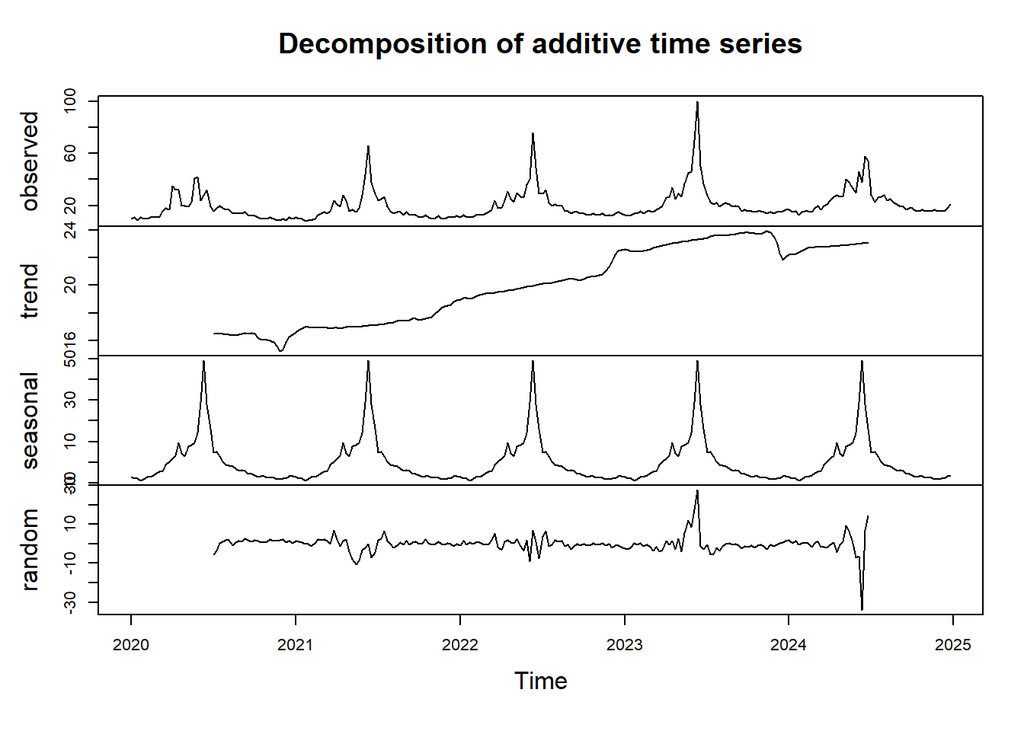

```r
plot(loratadineDecomp)
```

First, a time series variation of the data was made so that it could be analysed. Decomposing the data and looking at the respective plots, there is a very clear seasonal trend with the searches of Loratadine. When looking at the seasonal components, they are negative for most of the year, then for a couple weeks in summer the shoot upwards, reaching a peak of 49.104. This further tells us that interest in Loratadine is subdued throughout the majority of the year while its interest surges briefly in the summer months. Again, this corresponds to when experiences with hayfeaver are most pronounced.

Forecasting using the prophet function. Here, historical data is assigned to Hloratadine.

```r
Hloratadine <- prophet(loratadineDf)
```

```
## Disabling weekly seasonality. Run prophet with weekly.seasonality=TRUE to override this.
```

```
## Disabling daily seasonality. Run prophet with daily.seasonality=TRUE to override this.
```

Forecasting

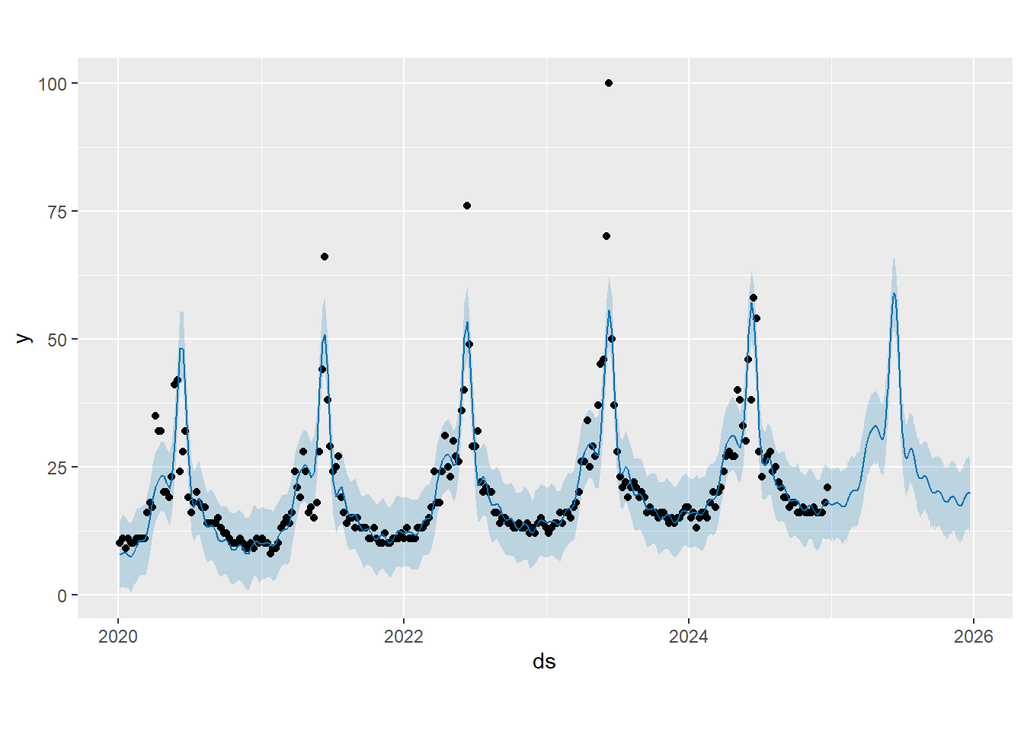

```r
future <- make_future_dataframe(Hloratadine, periods=365)
forecast <- predict(Hloratadine, future)
plot(Hloratadine, forecast)
```

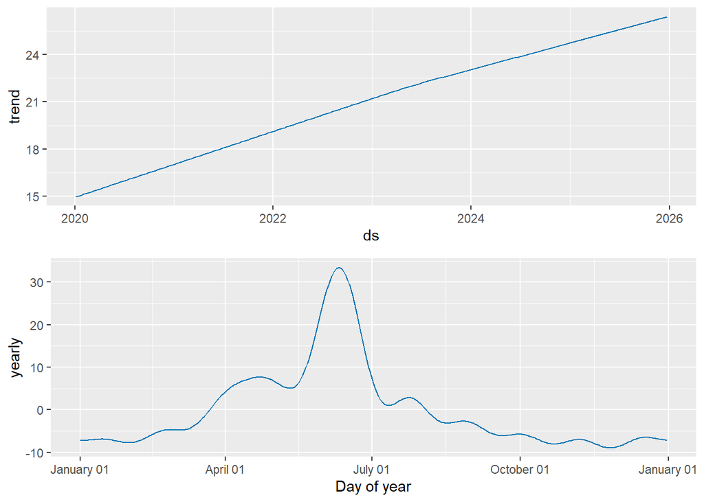

```r
prophet_plot_components(Hloratadine, forecast)
```

Using the prophet function, a forecast of how Loratadine will trend throughout 2025 has been made. The graph shows clear consistency with how the medicine has trended in the past. The component plot also shows that there has been an upwards trend in the interest of Loratadine year on year, alongside clear seasonality.